# Ford GoBike System Data Exploration

## Introduction

> This document explores a dataset with information containing 183,412 individual rides in a bike sharing system covering the greater San Fransisco bay area in 2019

## Preliminary Wrangling

```python
# import all packages and set plots to be embedded inline
import numpy as np
import pandas as pd
import matplotlib.pyplot as plt
import seaborn as sb

%matplotlib inline
```

```python
# Load in the dataset into a pandas dataframe, print statistics
ford_bike_share = pd.read_csv('201902-fordgobike-tripdata.csv')
```

```python
# high-level overview of data shape and composition
print(ford_bike_share.shape)
print(ford_bike_share.dtypes)
ford_bike_share.head(10)
```

```
(183412, 16)
duration_sec                 int64
start_time                  object
end_time                    object
start_station_id           float64
start_station_name          object
start_station_latitude     float64
start_station_longitude    float64
end_station_id             float64
end_station_name            object
end_station_latitude       float64
end_station_longitude      float64
bike_id                      int64
user_type                   object
member_birth_year          float64
member_gender               object
bike_share_for_all_trip     object
dtype: object
```

|  | duration_sec | start_time | end_time | start_station_id | start_station_name | start_station_latitude | start_station_longitude | end_station_id | end_station_name | end_station_latitude | end_station_longitude | bike_id | user_type | member_birth_year | member_gender | bike_share_for_all_trip |
| --- | --- | --- | --- | --- | --- | --- | --- | --- | --- | --- | --- | --- | --- | --- | --- | --- |
| 0 | 52185 | 2019-02-28 17:32:10.1450 | 2019-03-01 08:01:55.9750 | 21.0 | Montgomery St BART Station (Market St at 2nd St) | 37.789625 | -122.400811 | 13.0 | Commercial St at Montgomery St | 37.794231 | -122.402923 | 4902 | Customer | 1984.0 | Male | No |
| 1 | 42521 | 2019-02-28 18:53:21.7890 | 2019-03-01 06:42:03.0560 | 23.0 | The Embarcadero at Steuart St | 37.791464 | -122.391034 | 81.0 | Berry St at 4th St | 37.775880 | -122.393170 | 2535 | Customer | NaN | NaN | No |
| 2 | 61854 | 2019-02-28 12:13:13.2180 | 2019-03-01 05:24:08.1460 | 86.0 | Market St at Dolores St | 37.769305 | -122.426826 | 3.0 | Powell St BART Station (Market St at 4th St) | 37.786375 | -122.404904 | 5905 | Customer | 1972.0 | Male | No |
| 3 | 36490 | 2019-02-28 17:54:26.0100 | 2019-03-01 04:02:36.8420 | 375.0 | Grove St at Masonic Ave | 37.774836 | -122.446546 | 70.0 | Central Ave at Fell St | 37.773311 | -122.444293 | 6638 | Subscriber | 1989.0 | Other | No |
| 4 | 1585 | 2019-02-28 23:54:18.5490 | 2019-03-01 00:20:44.0740 | 7.0 | Frank H Ogawa Plaza | 37.804562 | -122.271738 | 222.0 | 10th Ave at E 15th St | 37.792714 | -122.248780 | 4898 | Subscriber | 1974.0 | Male | Yes |
| 5 | 1793 | 2019-02-28 23:49:58.6320 | 2019-03-01 00:19:51.7600 | 93.0 | 4th St at Mission Bay Blvd S | 37.770407 | -122.391198 | 323.0 | Broadway at Kearny | 37.798014 | -122.405950 | 5200 | Subscriber | 1959.0 | Male | No |
| 6 | 1147 | 2019-02-28 23:55:35.1040 | 2019-03-01 00:14:42.5880 | 300.0 | Palm St at Willow St | 37.317298 | -121.884995 | 312.0 | San Jose Diridon Station | 37.329732 | -121.901782 | 3803 | Subscriber | 1983.0 | Female | No |
| 7 | 1615 | 2019-02-28 23:41:06.7660 | 2019-03-01 00:08:02.7560 | 10.0 | Washington St at Kearny St | 37.795393 | -122.404770 | 127.0 | Valencia St at 21st St | 37.756708 | -122.421025 | 6329 | Subscriber | 1989.0 | Male | No |
| 8 | 1570 | 2019-02-28 23:41:48.7900 | 2019-03-01 00:07:59.7150 | 10.0 | Washington St at Kearny St | 37.795393 | -122.404770 | 127.0 | Valencia St at 21st St | 37.756708 | -122.421025 | 6548 | Subscriber | 1988.0 | Other | No |
| 9 | 1049 | 2019-02-28 23:49:47.6990 | 2019-03-01 00:07:17.0250 | 19.0 | Post St at Kearny St | 37.788975 | -122.403452 | 121.0 | Mission Playground | 37.759210 | -122.421339 | 6488 | Subscriber | 1992.0 | Male | No |

```python
# Check for duplicates
ford_bike_share.duplicated().sum()
```

```
0
```

```python
# Check for missing Values
ford_bike_share.isnull().sum()
```

```
duration_sec                  0
start_time                    0
end_time                      0
start_station_id            197
start_station_name          197
start_station_latitude        0
start_station_longitude       0
end_station_id              197
end_station_name            197
end_station_latitude          0
end_station_longitude         0
bike_id                       0
user_type                     0
member_birth_year          8265
member_gender              8265
bike_share_for_all_trip       0
dtype: int64
```

### What is the structure of your dataset?

> There are 183,412 rides in the dataset with 16 features (`'duration_sec','start_time', 'end_time', 'start_station_id', 'start_station_name', 'start_station_latitude', 'start_station_longitude', 'end_station_id', 'end_station_name', 'end_station_latitude', 'end_station_longitude', 'bike_id', 'user_type', 'member_birth_year', 'member_gender','bike_share_for_all_trip'`). Most Variables are numeric but the variables 'start_time', 'end_time' and 'member_birth_year' have the wrong data types.

> The variables `'start_station_id' (197), 'start_station_name' (197), 'end_station_id' (197), end_station_name (197), member_birth_year (8265), member_gender (8265)` all contain missing values.

### What is/are the main feature(s) of interest in your dataset?

> I am most interested in figuring out:
1. The average duration of rides taken
2. The day of the week and time of the day that most trips are taken
3. The relationship between user types and the answers to the two questions above and if steps can be taken to convert ordinary customers into Subscribers

### What features in the dataset do you think will help support your investigation into your feature(s) of interest?

> The main features of interest are `duration_sec`, `start_time`, `user_type`. I will be performing feature engineering on the main features of interest to extract the day of the week and time of day from the `start_time` feature to help answer the second question listed above. The `member_gender` and `member_birth_year` will also be very useful in getting more insight about user activity.

```python
#Create a copy of the dataset before to clean
ford_bike_new = ford_bike_share.copy()
```

```python
#Drop columns that a irrelevant to the analysis
ford_bike_new.drop(['end_time', 'start_station_id', 'start_station_latitude','start_station_longitude', 'bike_id',
                    'end_station_id', 'end_station_latitude', 'end_station_longitude', 'bike_share_for_all_trip'], axis = 1, inplace = True)
```

```python
ford_bike_new.head()
```

|  | duration_sec | start_time | start_station_name | end_station_name | user_type | member_birth_year | member_gender |
| --- | --- | --- | --- | --- | --- | --- | --- |
| 0 | 52185 | 2019-02-28 17:32:10.1450 | Montgomery St BART Station (Market St at 2nd St) | Commercial St at Montgomery St | Customer | 1984.0 | Male |
| 1 | 42521 | 2019-02-28 18:53:21.7890 | The Embarcadero at Steuart St | Berry St at 4th St | Customer | NaN | NaN |
| 2 | 61854 | 2019-02-28 12:13:13.2180 | Market St at Dolores St | Powell St BART Station (Market St at 4th St) | Customer | 1972.0 | Male |
| 3 | 36490 | 2019-02-28 17:54:26.0100 | Grove St at Masonic Ave | Central Ave at Fell St | Subscriber | 1989.0 | Other |
| 4 | 1585 | 2019-02-28 23:54:18.5490 | Frank H Ogawa Plaza | 10th Ave at E 15th St | Subscriber | 1974.0 | Male |

```python
ford_bike_new.dtypes
```

```
duration_sec            int64
start_time             object
start_station_name     object
end_station_name       object
user_type              object
member_birth_year     float64
member_gender          object
dtype: object
```

```python
#Convert start_time data type from object to datatime
ford_bike_new['start_time'] = pd.to_datetime(ford_bike_new['start_time'])
```

```python
#Extract time of the day from start_time
ford_bike_new['start_hour'] = ford_bike_new['start_time'].apply(lambda x: x.hour)

def getTimeOfDay(time):
    hour = time.hour
    if hour >=0 and hour <12:
        return 'Morning'
    if hour >= 12 and hour < 16:
        return 'Afternoon'
    if hour >= 16 and hour <= 19:
        return 'Evening'
    if hour > 19 and hour < 24:
        return 'Night'

ford_bike_new['day_time'] = ford_bike_new['start_time'].apply(lambda time: getTimeOfDay(time))
```

```python
day_order = ['Morning', 'Afternoon', 'Evening', 'Night']
dorder = pd.api.types.CategoricalDtype(ordered = True, categories = day_order)
```

```python
ford_bike_new['day_time'] = ford_bike_new['day_time'].astype(dorder)
```

```python
#Extract day of the week from start_time
ford_bike_new['day_of_week'] = pd.DatetimeIndex(ford_bike_new['start_time']).strftime('%A')
```

```python
week_order = ['Sunday', 'Monday', 'Tuesday', 'Wednesday', 'Thursday', 'Friday', 'Saturday']
worder = pd.api.types.CategoricalDtype(ordered = True, categories = week_order)
ford_bike_new['day_of_week'] = ford_bike_new['day_of_week'].astype(worder)
```

```python
#Calculate the user age using 2023 as the current year
ford_bike_new['user_age'] = ford_bike_new['member_birth_year'].apply(lambda x: 2023 - x)
```

```python
ford_bike_new.head(5)
```

|  | duration_sec | start_time | start_station_name | end_station_name | user_type | member_birth_year | member_gender | start_hour | day_time | day_of_week | user_age |
| --- | --- | --- | --- | --- | --- | --- | --- | --- | --- | --- | --- |
| 0 | 52185 | 2019-02-28 17:32:10.145 | Montgomery St BART Station (Market St at 2nd St) | Commercial St at Montgomery St | Customer | 1984.0 | Male | 17 | Evening | Thursday | 39.0 |
| 1 | 42521 | 2019-02-28 18:53:21.789 | The Embarcadero at Steuart St | Berry St at 4th St | Customer | NaN | NaN | 18 | Evening | Thursday | NaN |
| 2 | 61854 | 2019-02-28 12:13:13.218 | Market St at Dolores St | Powell St BART Station (Market St at 4th St) | Customer | 1972.0 | Male | 12 | Afternoon | Thursday | 51.0 |
| 3 | 36490 | 2019-02-28 17:54:26.010 | Grove St at Masonic Ave | Central Ave at Fell St | Subscriber | 1989.0 | Other | 17 | Evening | Thursday | 34.0 |
| 4 | 1585 | 2019-02-28 23:54:18.549 | Frank H Ogawa Plaza | 10th Ave at E 15th St | Subscriber | 1974.0 | Male | 23 | Night | Thursday | 49.0 |

## Univariate Exploration

> i'll start by looking at the main variables of interest `duration_sec`, `start_hour`, `time_of_day`, `day_of_week`, `user_type`

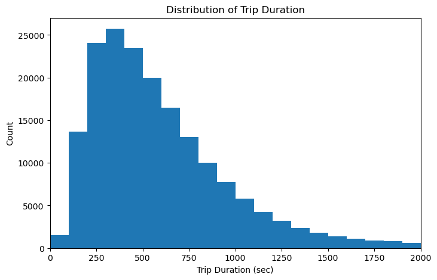

```python
# Start with a standard scaled plot
bin_size = 100
bins=np.arange(0, (ford_bike_new['duration_sec'].max())+ bin_size, bin_size)

plt.figure(figsize=[8, 5])
plt.hist(data = ford_bike_new, x = 'duration_sec', bins = bins );
plt.xlim(0, 2000)
plt.title('Distribution of Trip Duration')
plt.xlabel('Trip Duration (sec)')
plt.ylabel('Count')

plt.show()
```

Trip duration has a highly skewed distribution with a really long tail. plotting the duration_sec variable on a log scale was not very helpful because the distribution became skewed to the right. I will have to convert the trip duration from seconds to minutes before plotting on a log scales.

```python
#Convert the trip duration variable to minutes
ford_bike_new['trip_duration'] = ford_bike_new['duration_sec']/60

#View
ford_bike_new.head()
```

|  | duration_sec | start_time | start_station_name | end_station_name | user_type | member_birth_year | member_gender | start_hour | day_time | day_of_week | user_age | trip_duration |
| --- | --- | --- | --- | --- | --- | --- | --- | --- | --- | --- | --- | --- |
| 0 | 52185 | 2019-02-28 17:32:10.145 | Montgomery St BART Station (Market St at 2nd St) | Commercial St at Montgomery St | Customer | 1984.0 | Male | 17 | Evening | Thursday | 39.0 | 869.750000 |
| 1 | 42521 | 2019-02-28 18:53:21.789 | The Embarcadero at Steuart St | Berry St at 4th St | Customer | NaN | NaN | 18 | Evening | Thursday | NaN | 708.683333 |
| 2 | 61854 | 2019-02-28 12:13:13.218 | Market St at Dolores St | Powell St BART Station (Market St at 4th St) | Customer | 1972.0 | Male | 12 | Afternoon | Thursday | 51.0 | 1030.900000 |
| 3 | 36490 | 2019-02-28 17:54:26.010 | Grove St at Masonic Ave | Central Ave at Fell St | Subscriber | 1989.0 | Other | 17 | Evening | Thursday | 34.0 | 608.166667 |
| 4 | 1585 | 2019-02-28 23:54:18.549 | Frank H Ogawa Plaza | 10th Ave at E 15th St | Subscriber | 1974.0 | Male | 23 | Night | Thursday | 49.0 | 26.416667 |

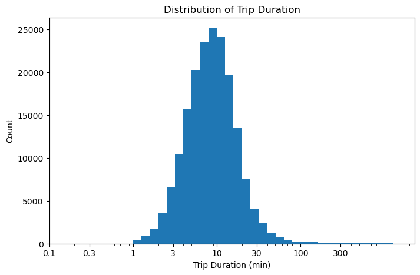

```python
# Plot trip duration on a log scale
log_bins = 0.1
bins=10 ** np.arange(0, np.log10(ford_bike_new['trip_duration'].max())+ log_bins, log_bins)

plt.figure(figsize=[8, 5])
plt.hist(data = ford_bike_new, x = 'trip_duration', bins = bins );
plt.xscale('log')
ticks = [0.1, 0.3, 1, 3, 10, 30, 100, 300]
labels = ['{}'.format(v) for v in ticks]
plt.xticks(ticks, labels)
plt.title('Distribution of Trip Duration')
plt.xlabel('Trip Duration (min)')
plt.ylabel('Count')

plt.show()
```

```python
ford_bike_new['trip_duration'].mean()
```

```
12.10130725724969
```

The distribution of trip duration is unimodal when the `duration_sec` variable is converted to minutes and plotted on a log scale, with the peak just under 10 minutes. Interestingly the average trip duration is around 12 minutes.

I'll now look at other features of interest. Next up, `start_hour`.

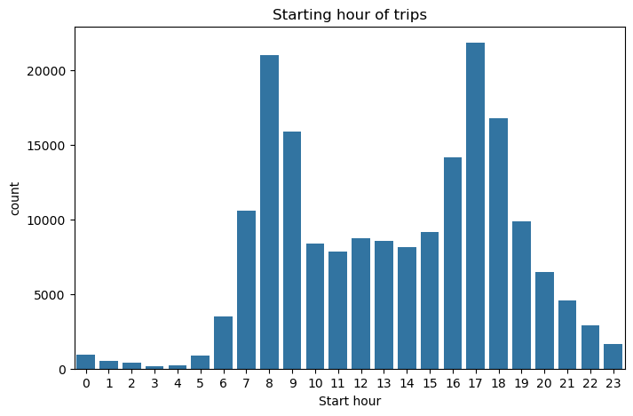

```python
# Plot distribution of day of week
base_color = sb.color_palette()[0]

plt.figure(figsize= [8, 5])
sb.countplot(data = ford_bike_new, x = 'start_hour', color = base_color)
plt.xlabel('Start hour')
plt.title('Starting hour of trips')
plt.show()
```

The above bar chart shows that majority of trips are started between 8-9am and 5-6pm. This makes sense because most people tend to leave for work between 8-9am and leave the office between 5-6pm.

I'll move on to other variables in the dataset, `user_type` and `member_gender`

```python
#Get the percentage count of user_type
user_type_pct = 100 * ford_bike_new['user_type'].value_counts()/ford_bike_new['user_type'].value_counts().sum()
print('User type pecentages')
print(user_type_pct)
```

```
User type pecentages
Subscriber    89.167557
Customer      10.832443
Name: user_type, dtype: float64
```

```python
#Get the percentage count of member gender
member_gender_pct = 100 * ford_bike_new['member_gender'].value_counts()/ford_bike_new['member_gender'].value_counts().sum()
print('Member gender pecentages')
print(member_gender_pct)
```

```
Member gender pecentages
Male      74.595054
Female    23.319840
Other      2.085106
Name: member_gender, dtype: float64
```

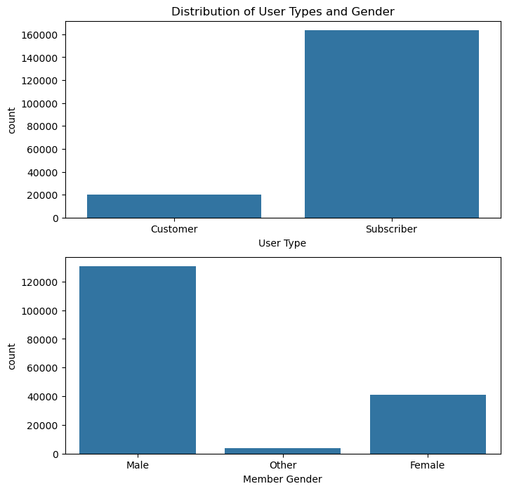

```python
#Plot the distibution of rider attributes, user_type and member_gender
fig, ax = plt.subplots(nrows = 2, figsize = [8, 8])
base_color = sb.color_palette()[0]
sb.countplot(data = ford_bike_new, x = 'user_type', ax = ax[0], color= base_color )
sb.countplot(data = ford_bike_new, x = 'member_gender', ax = ax[1], color = base_color)
ax[0].set_title('Distribution of User Types and Gender')
ax[0].set_xlabel('User Type')
ax[1].set_xlabel('Member Gender')
plt.show()
```

- Approximately 89% of the total number of trips (163,544) were taken by subscribers with the remaining 11% (19,868) taken by casual riders. This is not strange because Subscriber are most likely using the rides for their daily movement while causal riders would tend to use the rides for leisure activities.
- Also, almost 75% (130,651) of rides were taken by men while women took approximately 23% (40,844) of the total number of rides. 2% was taken by 'Other' gender.

Now lets take a look at trips by day of the week

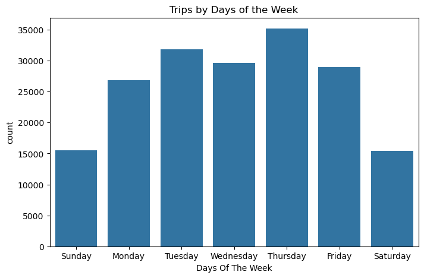

```python
plt.figure(figsize= [8, 5]);
week_order = ['Sunday','Monday', 'Tuesday', 'Wednesday', 'Thursday', 'Friday', 'Saturday']
base_color = sb.color_palette()[0]
sb.countplot(data = ford_bike_new, x = 'day_of_week', order = week_order, color = base_color)
plt.xlabel('Days Of The Week')
plt.title('Trips by Days of the Week')

plt.show()
```

Thursday is the day with the day with the most number of trips followed by Tuesday and Wednesday. Saturday and Sunday are the days with the least number of trips, this might be due to the fact that subscribers (who take to most number of trips) do not go to work on the weekends. Further investigation would need to be done to confirm this theory.

Next, i will be taking a look at distribution by `time_of_day`

```python
# Get the percentage count of trips made by time of the day
print(ford_bike_new['day_time'].value_counts())
print('\n')
print(np.round(100 * ford_bike_new['day_time'].value_counts()/ford_bike_new['day_time'].value_counts().sum(),1))
```

```
Morning      70465
Evening      62741
Afternoon    34601
Night        15605
Name: day_time, dtype: int64


Morning      38.4
Evening      34.2
Afternoon    18.9
Night         8.5
Name: day_time, dtype: float64
```

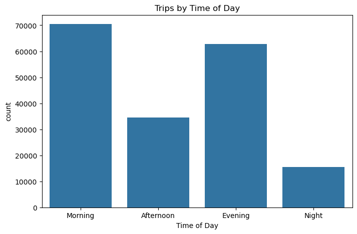

```python
#plot the distribution of trips by time of day
plt.figure(figsize=[8, 5]);
day_order = ['Morning', 'Afternoon', 'Evening', 'Night']
base_color = sb.color_palette()[0]
sb.countplot(data = ford_bike_new, x = 'day_time', color = base_color, order=day_order)
plt.title('Trips by Time of Day')
plt.xlabel('Time of Day')
plt.show()
```

The plot shows that the time of the day with the most trips is in the morning with 70,465 (38.4%) trips taken while night has the lowest with 15605 (8.5%) trips taken. This is expected because of the number of people who are heading to work or have places to be. i will perform further analysis to determine if this is related to the user type.

Before closing this section, we'll take a look at the last variables: `user_age`.

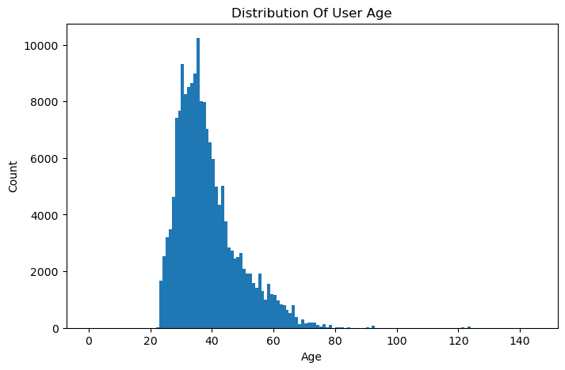

```python
# start with a standard-scaled plot
bin_size = 1
bins = np.arange(0, ford_bike_new['user_age'].max()+bin_size,bin_size)
plt.figure(figsize = [8, 5])
plt.hist(data = ford_bike_new, x = 'user_age', bins = bins )
plt.xlabel('Age')
plt.ylabel('Count')
plt.title('Distribution Of User Age')
plt.show()
```

The distribution of user age is skewed with a long tail but we can see that users between the ages of 20 and 40 took the most number of trips. I would need to create an `age_group` variable to group the users into different age groups and plot it in a bar chart to give us a clearer understanding of the age distribution of users.

```python
#Group users into different age groups
def useragegroup(user_age):
    if user_age >=10 and user_age <=20:
        return '10 - 20'
    if user_age > 20 and user_age <= 30:
        return '21 - 30'
    if user_age > 30 and user_age <= 40:
        return '31 - 40'
    if user_age > 40 and user_age <= 50:
        return '41 - 50'
    if user_age > 50 and user_age <= 60:
        return '51 - 60'
    if user_age > 60 and user_age <= 70:
        return '61 - 70'
    if user_age > 70 and user_age <= 80:
        return '71 - 80'
    if user_age > 80:
        return '81 and above'

ford_bike_new['age_group'] = ford_bike_new['user_age'].apply(useragegroup)

#View dataframe
ford_bike_new.head(5)
```

|  | duration_sec | start_time | start_station_name | end_station_name | user_type | member_birth_year | member_gender | start_hour | day_time | day_of_week | user_age | trip_duration | age_group |
| --- | --- | --- | --- | --- | --- | --- | --- | --- | --- | --- | --- | --- | --- |
| 0 | 52185 | 2019-02-28 17:32:10.145 | Montgomery St BART Station (Market St at 2nd St) | Commercial St at Montgomery St | Customer | 1984.0 | Male | 17 | Evening | Thursday | 39.0 | 869.750000 | 31 - 40 |
| 1 | 42521 | 2019-02-28 18:53:21.789 | The Embarcadero at Steuart St | Berry St at 4th St | Customer | NaN | NaN | 18 | Evening | Thursday | NaN | 708.683333 | None |
| 2 | 61854 | 2019-02-28 12:13:13.218 | Market St at Dolores St | Powell St BART Station (Market St at 4th St) | Customer | 1972.0 | Male | 12 | Afternoon | Thursday | 51.0 | 1030.900000 | 51 - 60 |
| 3 | 36490 | 2019-02-28 17:54:26.010 | Grove St at Masonic Ave | Central Ave at Fell St | Subscriber | 1989.0 | Other | 17 | Evening | Thursday | 34.0 | 608.166667 | 31 - 40 |
| 4 | 1585 | 2019-02-28 23:54:18.549 | Frank H Ogawa Plaza | 10th Ave at E 15th St | Subscriber | 1974.0 | Male | 23 | Night | Thursday | 49.0 | 26.416667 | 41 - 50 |

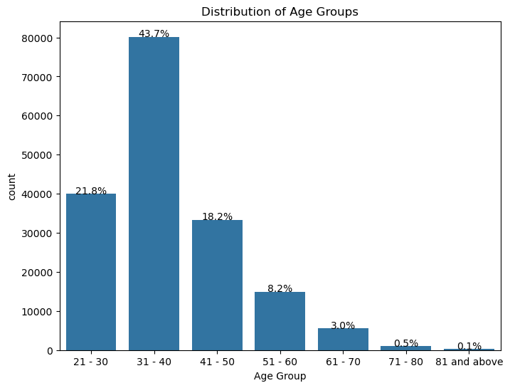

```python
# plot distribution of User Age Groups
plt.figure(figsize=[8, 6])
base_color = sb.color_palette()[0]
sb.countplot(data = ford_bike_new.sort_values(['age_group']), x = 'age_group', color = base_color)
n_points = ford_bike_new.shape[0]
user_counts = ford_bike_new['age_group'].value_counts()
locs, labels = plt.xticks()

# print frequency on the bar chart
for loc, label in zip(locs, labels):
    count = user_counts[label.get_text()]
    pct_string = '{:0.1f}%'.format(100*count/n_points)
    plt.text(loc, count-8, pct_string, ha='center')

plt.title('Distribution of Age Groups')
plt.xlabel('Age Group')
plt.ylabel("count")
plt.show()
```

Over 65% of users are between the ages of 21 - 40. This means that people between 21 to 40 took more trips than every other age group put together. I would like to peform further analysis to determine if there is a relationship between the age_group of users and the duration of trips.

### Discuss the distribution(s) of your variable(s) of interest. Were there any unusual points? Did you need to perform any transformations?

> The distribution of `duration_sec` was skewed with a very long tail, I had to to create a new variable for trip duration measured in minutes `trip_duration` and then I plotted it on a log scale which made the distribution to look unimodal with a peak just under 10 minutes.

> The distribution of `user_age` variable that i was able to create by substracting the `member_birth_year` from the current year *2023* was also very skewed due to the fact that a huge percentage of user are between the ages of 20 - 40, i treated this by grouping the ages and this resulted in a less skewed plot

> The plots for `member_gender`, `user_type`, `day_of_week`, `day_time`, `start_hour` were not as complicated and i was able to get the following insights about the dataset from them.

Majority of trips are started between 8-9am and 5-6pm. This makes sense because most people tend to leave for work between 8-9am and leave the office between 5-6pm.

Approximately 89% of the total number of trips (163,544) were taken by subscribers with the remaining 11% (19,868) taken by casual riders. This is not strange because Subscriber are most likely using the rides for their daily movement while causal riders would tend to use the rides for leisure activities.

Almost 75% (130,651) of rides were taken by men while women took approximately 23% (40,844) of the total number of rides. 2% was taken by 'other' gender.

The time of the day with the most trips is in the morning with 70,465 (38.4%) trips taken while night has the lowest with 15605 (8.5%) trips taken. This is expected because of the number of people who are heading to work or have places to be.

## Bivariate Exploration

> To start off with, I want to look at the pairwise correlations present between features in the data.

```python
ford_bike_new.info()
```

```
<class 'pandas.core.frame.DataFrame'>
RangeIndex: 183412 entries, 0 to 183411
Data columns (total 13 columns):
 #   Column              Non-Null Count   Dtype
---  ------              --------------   -----
 0   duration_sec        183412 non-null  int64
 1   start_time          183412 non-null  datetime64[ns]
 2   start_station_name  183215 non-null  object
 3   end_station_name    183215 non-null  object
 4   user_type           183412 non-null  object
 5   member_birth_year   175147 non-null  float64
 6   member_gender       175147 non-null  object
 7   start_hour          183412 non-null  int64
 8   day_time            183412 non-null  category
 9   day_of_week         183412 non-null  category
 10  user_age            175147 non-null  float64
 11  trip_duration       183412 non-null  float64
 12  age_group           175147 non-null  object
dtypes: category(2), datetime64[ns](1), float64(3), int64(2), object(5)
memory usage: 15.7+ MB
```

```python
numeric_vars = ['trip_duration', 'start_hour', 'user_age']
categoric_vars = ['user_type', 'member_gender', 'day_of_week', 'day_time']
```

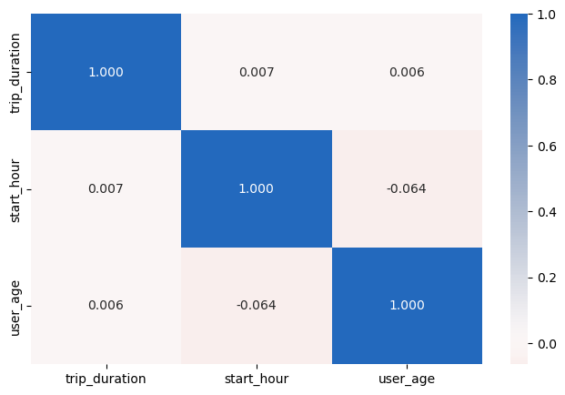

```python
# Correlation Plot
plt.figure(figsize = [8, 5])
sb.heatmap(data = ford_bike_new[numeric_vars].corr(), annot = True, fmt = '.3f',
           cmap = 'vlag_r', center = 0)

plt.show()
```

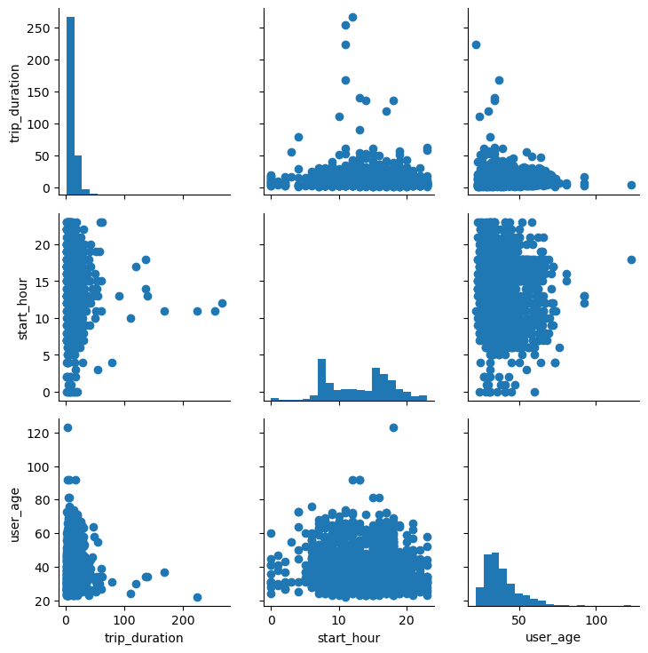

```python
#Plot Matix: sample 2000 trips so that the plots are clearer and they render faster
samples = np.random.choice(ford_bike_new.shape[0], 2000, replace = False)
ford_samp = ford_bike_new.loc[samples,:]

g = sb.PairGrid(data = ford_samp, vars = numeric_vars)
g = g.map_diag(plt.hist, bins = 20)
g.map_offdiag(plt.scatter)

plt.show()
```

From the plot we can see that `user_age`, `trip_duration` and `start_hour` don't have a correlation with one another but I would like to investigate further to see if there is a correlation between `age_group` and `trip_duration`.

### Is the average duration of trips taken dependent on the age group of the riders?

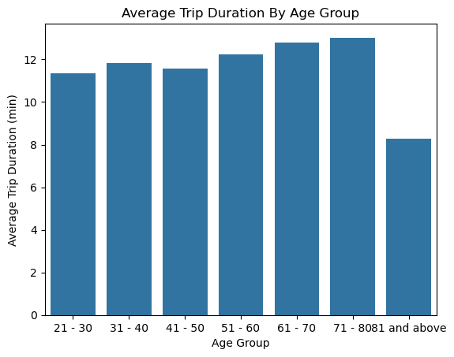

```python
# Calculate the average trip duration by age group
age_group_trips = ford_bike_new.groupby('age_group')['trip_duration'].mean()

#Convert age_group_trips to a table using reset index
age_group_trips = age_group_trips.reset_index( name = 'average_duration')

#Plot average trip duration vs age group
base_color = sb.color_palette()[0]
sb.barplot(data = age_group_trips, x = 'age_group', y = 'average_duration', color = base_color)
plt.xlabel('Age Group')
plt.ylabel('Average Trip Duration (min)')
plt.title('Average Trip Duration By Age Group')
plt.show()
```

Let's move on to looking at how user_type and trip duration correlate.

### What is the relationship between Trip duration and User type?

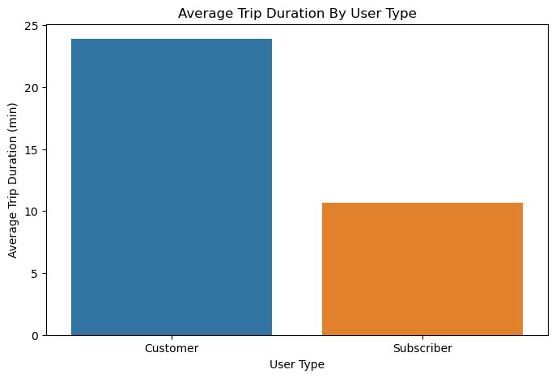

```
    user_type  average_duration
0    Customer              23.9
1  Subscriber              10.7
```

```python
# Calculate the average trip duration by user type
user_type_trips = np.round(ford_bike_new.groupby('user_type')['trip_duration'].mean(),1)

#Convert age_group_trips to a table using reset index
user_type_trips = user_type_trips.reset_index( name = 'average_duration')

plt.figure(figsize=[8,5])
sb.barplot(data = user_type_trips, x = 'user_type', y = 'average_duration')
plt.xlabel('User Type')
plt.ylabel('Average Trip Duration (min)')
plt.title('Average Trip Duration By User Type')
plt.show()

print(user_type_trips)
```

In the plot above we can see that Customers (23.9 minutes) spent more time on trips on average than Subscribers (10.7 minutes). This might be because Subscribers mostly used the rides for short everyday comutes like going from home to work or to school while Customers might want to use the bikes for recreational activites during the weekends

Lets look at the average trip duration by that day of the week to find out more.

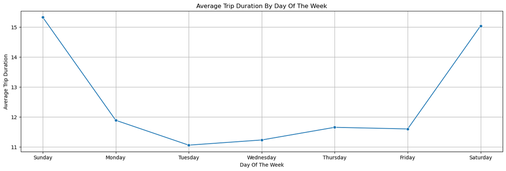

```python
# Calculate the average trip duration by age day of the week
avg_ride_by_week = ford_bike_new[['day_of_week','trip_duration']].groupby(['day_of_week'],as_index= False).mean()

plt.figure(figsize = [17, 5])
sb.lineplot(data = avg_ride_by_week, x = 'day_of_week', y = 'trip_duration', marker = 'o')
plt.xlabel('Day Of The Week')
plt.ylabel('Average Trip Duration')
plt.title('Average Trip Duration By Day Of The Week')
plt.grid()
plt.show();
```

Sundays and Saturdays have the highest Average trip durations as expected as those are the two days that Customers would be free to take long trips.

### Number Of Rides On Days Of The Week By User Type

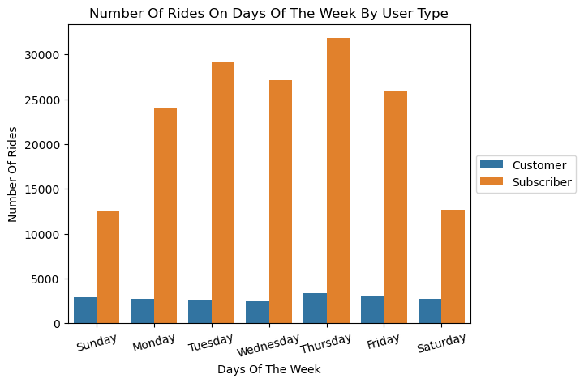

```python
 # plot a graph to see how different user types ride each day of week
sb.countplot(data = ford_bike_new, x = 'day_of_week', hue = 'user_type')
plt.xlabel('Days Of The Week')
plt.ylabel('Number Of Rides')
plt.xticks(rotation = 15)
plt.title('Number Of Rides On Days Of The Week By User Type')
plt.legend(loc='center left', bbox_to_anchor=(1, 0.5))
plt.show()
```

From the bar chart above, we can see that the day of the week that the highest number of trips (Thursday) is not dependent on the user type. The graph also shows that there is a reduction in the number of rides taken by Subscribers on Saturdays and Sundays, this is understandable because a lot of subscribers do not have to go to work during the weekends. As for casaul riders, there is not major change in the number of rides taken on different days of the week.

### What time of the day rides are taken for each day of the week?

```
<function matplotlib.pyplot.show(close=None, block=None)>
```

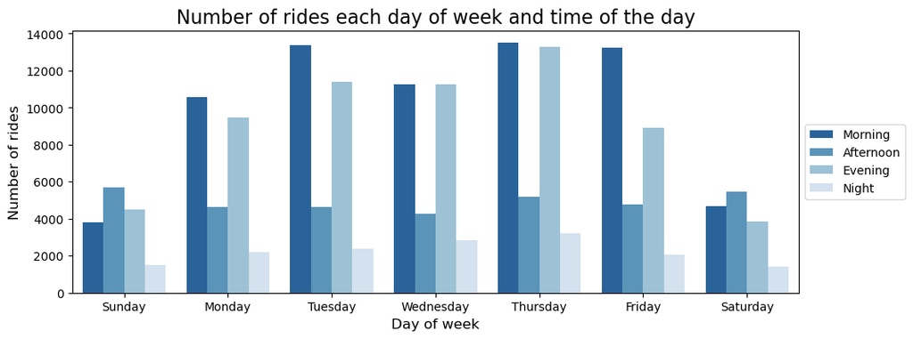

```python
# plot a graph to see what time of the day rides are taken for each day of the week

plt.figure(figsize=[11, 4])
sb.countplot(data = ford_bike_new, x = 'day_of_week', hue = 'day_time',  palette='Blues_r')
plt.xlabel('Day of week', fontsize=12)
plt.ylabel('Number of rides', fontsize=12)
plt.title('Number of rides each day of week and time of the day', fontsize=16)
plt.legend(title = 'Time of the day');
plt.legend(loc='center left', bbox_to_anchor=(1, 0.5))
plt.show
```

### Relationships observed in this part of the investigation. How did the feature(s) of interest vary with other features in the dataset?

Customers (23.9 minutes) spent more time on trips on average than Subscribers (10.7 minutes)

The day of the week that the highest number of rides are taken (Thursday) is not dependent on the user type

Sundays and Saturdays have the highest Average trip durations

## Multivariate Exploration

Average trip duration for each user_type by the days of the week

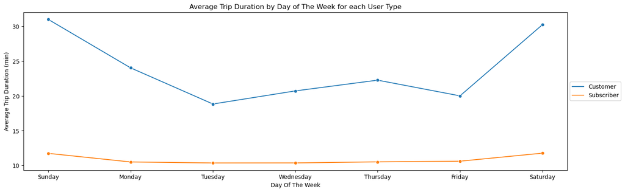

```python
weekday_avg_use = ford_bike_new.groupby(['user_type','day_of_week']).trip_duration.mean()
weekday_avg_use = weekday_avg_use.reset_index()

# line plot with colors based on user_type
plt.figure(figsize=[17,5])
sb.lineplot(data = weekday_avg_use, x='day_of_week', y='trip_duration', hue='user_type', marker='o')
plt.title("Average Trip Duration by Day of The Week for each User Type")
plt.ylabel('Average Trip Duration (min)');
plt.xlabel('Day Of The Week')
plt.legend(loc='center left', bbox_to_anchor=(1, 0.5))
plt.show()
```

Customers had longer rides on average than Subscribers for every day of the week with Sundays and Saturdays being signifantly higher than the rest of the week days

Average trip duration by time of the day for each user_type

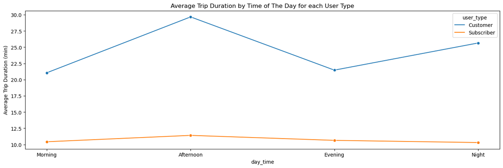

```python
avg_trip_by_user = ford_bike_new.groupby(['user_type','day_time']).trip_duration.mean()
avg_trip_by_user = avg_trip_by_user.reset_index()

# line plot with colors based on user_type
plt.figure(figsize=[17,5])
sb.lineplot(data = avg_trip_by_user, x = 'day_time', y = 'trip_duration', hue = 'user_type', marker = 'o')
plt.title("Average Trip Duration by Time of The Day for each User Type")
plt.ylabel('Average Trip Duration (min)');
plt.show()
```

The Average trip duration for each time of the day for the Subscribers is relatively constant with slight increase in the afternoon while for Customers the average trip duration increases significantly in the afternoon and at night.

### Were there features that strengthened each other in terms of looking at your feature(s) of interest?

> The Further investigation stengthened my initial observation that Customers spend more time on rides than Subscribers during the weekends and at everytime of the day. It is safe to say that there really is a dependency of average trip duration on if the user is a Subscriber or a Customer.

### Were there any interesting or surprising interactions between features?

> I did not find any thing suprising between these feature as the observations are inline with my initial theory that customers spend more time on the bikes on average.